# Hairy Football Challenge

Calculate mean times between winning streaks of football clubs using sliding window calculations.

Julian During www.datannery.com  
2025-11-15

# Idea

Recently I came across a trend on social media: A football fan states ‘I won’t cut my hair until club ’X’ wins 5 games in a row’.

I asked myself the question: How long would this presumably be for my favorite club? Is it time to join the challenge?

# Data

In this analysis the following libraries are used:

```r
library(tarchetypes)
library(conflicted)
library(tidyverse)
library(targets)
library(RSQLite)
library(assertr)
library(distill)
library(slider)
library(httr2)
library(DBI)
library(fs)
library(gt)

conflicts_prefer(dplyr::filter)
conflicts_prefer(dplyr::lag)
```

To answer the initial question I use a data set from [kaggle](https://www.kaggle.com/). It can be found under the following URL:

```r
base_url <- "https://www.kaggle.com/api/v1/datasets/download/hugomathien/soccer"
```

Before we can start analyzing the data we need to download it:

- Request and save the raw zip data using function from the `httr2` package (Wickham 2025a)
- Unzip the downloaded file with the `unzip` (R Core Team 2024) function
- Delete the zip file (Hester, Wickham, and Csárdi 2025) and return the sqlite file

```r
download_data <- function(base_url) {
  kaggle_req <- request(base_url) |>
    req_auth_basic(
      username = Sys.getenv("kaggle_user"), password = Sys.getenv("kaggle_key")
    )

  zip_path <- req_perform(kaggle_req, path = "soccer.zip")

  db_path <- unzip(zip_path$body, overwrite = TRUE)
  file_delete(zip_path$body)

  return(db_path)
}
db_file <- download_data(base_url)
```

The environment variables `kaggle_user` and `kaggle_key` can be created on the kaggle website

We now have a sqlite file in our project folder that we want to further investigate. As a first step we want to filter the included match data for a specific club.

- Create a connection to the file using ‘DBI’ (R Special Interest Group on Databases (R-SIG-DB), Wickham, and Müller 2024) and ‘RSQLite’ (Müller et al. 2025)
- Filter and transform the data using the Tidyverse suite of packages (Wickham 2023)
- By using the ‘dplyr’ (Wickham et al. 2023) functions, the Tidyverse pipelines get translated to SQL automatically. We simply need to call the ‘collect’ function at the end of the pipeline
- Add an assertive test (Fischetti 2023) to make sure the key variable (`id`) is unique

Search the database for games of my club:

```r
club_games_raw <- function(db_file, club_name) {
  con <- dbConnect(SQLite(), db_file)
  on.exit(dbDisconnect(con))

  qry_club <- tbl(con, "Team") |>
    filter(team_long_name == club_name) |>
    select(team_api_id, team_long_name)

  qry_club_games <- tbl(con, "Match") |>
    select(id, home_team_api_id, away_team_api_id) |>
    pivot_longer(
      cols = c(home_team_api_id, away_team_api_id),
      values_to = "team_api_id", names_to = "home_away"
    ) |>
    inner_join(qry_club, by = join_by(team_api_id))

  df_club_games_raw <- tbl(con, "Match") |>
    inner_join(qry_club_games, by = join_by(id)) |>
    select(
      id, league_id, team_long_name, date, home_team_api_id, away_team_api_id,
      home_team_goal, away_team_goal, home_away
    ) |>
    collect()

  df_club_games_raw |>
    assert(is_uniq, id)
}
df_bvb_games_raw <- club_games_raw(db_file, "Borussia Dortmund")
```

Let’s take a first look at the data:

```r
glimpse(df_bvb_games_raw)
```

```
Rows: 272
Columns: 9
$ id               <int> 7829, 7846, 7864, 7883, 7891, 7909, 7918, 7…
$ league_id        <int> 7809, 7809, 7809, 7809, 7809, 7809, 7809, 7…
$ team_long_name   <chr> "Borussia Dortmund", "Borussia Dortmund", "…
$ date             <chr> "2008-11-02 00:00:00", "2008-11-15 00:00:00…
$ home_team_api_id <int> 9789, 9789, 9789, 9789, 9789, 9789, 9789, 9…
$ away_team_api_id <int> 9911, 9810, 8721, 9788, 8178, 9823, 8398, 8…
$ home_team_goal   <int> 1, 4, 0, 2, 1, 1, 1, 0, 1, 3, 2, 4, 6, 3, 3…
$ away_team_goal   <int> 1, 0, 0, 1, 1, 1, 1, 0, 0, 1, 0, 0, 0, 3, 0…
$ home_away        <chr> "home_team_api_id", "home_team_api_id", "ho…
```

Now that the data is locally available, we can further preprocess it using the full R functionality (which might be hard or impossible to translate into SQL):

- Parse the date column (Spinu, Grolemund, and Wickham 2024)
- Split the `home_away` column and extract the first part of the string (Wickham 2025b)
- Determine if the result represents a ‘victory’
- Make sure the date column is unique (assuming there can’t be two matches at the same day)

```r
club_games <- function(df_club_games_raw) {
  df_club_games <- df_club_games_raw |>
    mutate(
      team_long_name,
      date = as_date(ymd_hms(date)),
      home_away = str_split_i(home_away, "_", 1),
      victory = if_else(
        home_away == "home",
        home_team_goal > away_team_goal,
        away_team_goal > home_team_goal
      ), .keep = "none"
    )

  df_club_games |>
    assert(is_uniq, date)
}
df_bvb_games <- club_games(df_bvb_games_raw)
```

The data is now in the right form to perform calculations across a sliding window (Vaughan 2024). Before continuing, define after how many victories in a row we are talking about a ‘streak’:

```r
victories_streak <- 5L
```

Now to the sliding window calculations:

- How many victories are achieved in a row
- Calculate the number of the streak

```r
club_winning_streak <- function(df_club_games, victories_streak) {
  df_club_games |>
    arrange(date) |>
    mutate(
      victories_in_a_row = slide_int(
        victory, \(x) sum(cumall(rev(x))),
        .before = Inf
      ),
      winning_streak_nr = cumsum(
        victories_in_a_row >= victories_streak &
          lag(victories_in_a_row < victories_streak, default = 0)
      )
    )
}
df_bvb_winning_streak <- club_winning_streak(df_bvb_games, victories_streak)
```

After the sliding window calculation, we filter observations that represent the last winning streak. Also clubs with less than two winning streaks are filtered out.

```r
mean_days_between_streaks <- function(df_club_winning_streak) {
  df_club_winning_streak |>
    filter(
      winning_streak_nr != max(winning_streak_nr),
      max(winning_streak_nr) >= 2
    ) |>
    group_by(team_long_name, winning_streak_nr) |>
    summarise(
      min_date = min(date), max_date = max(date), .groups = "drop_last"
    ) |>
    mutate(
      days_between_streaks = difftime(max_date, min_date, units = "days")
    ) |>
    summarise(
      mean_days_between_streaks = round(
        mean(days_between_streaks, na.rm = TRUE), 2
      )
    )
}
df_bvb_mean_days_between_streaks <- mean_days_between_streaks(df_bvb_winning_streak)
```

Now that the data is in the right form, we can visualise it. Create a combination of a “Step” and a “Point” plot with ‘ggplot2’ (Wickham et al. 2025)

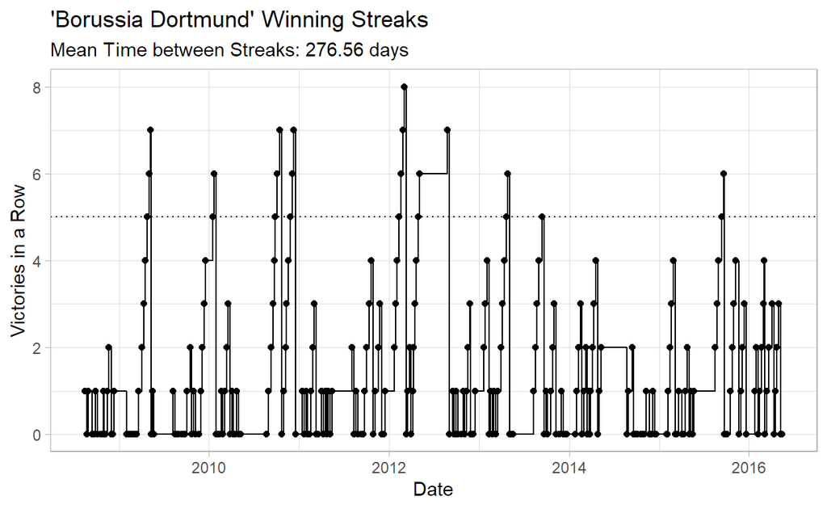

```r
vis_winning_streak <- function(df_club_winning_streak,
                               df_club_mean_days_between_streaks) {
  df_club_winning_streak |>
    ggplot(aes(x = date, y = victories_in_a_row)) +
    geom_point() +
    geom_step() +
    geom_hline(yintercept = 5, linetype = "dotted") +
    theme_light() +
    labs(
      title = str_glue(
        "'{df_club_mean_days_between_streaks$team_long_name}' Winning Streaks"
      ),
      subtitle = str_glue(
        "Mean Time between Streaks: ",
        "{df_club_mean_days_between_streaks$mean_days_between_streaks} days"
      ),
      y = "Victories in a Row", x = "Date"
    )
}
gg_winning_streak <- vis_winning_streak(df_bvb_winning_streak, df_bvb_mean_days_between_streaks)
```

If we repeat the process of all clubs, we can look at the top 10 clubs with the lowest mean time between winning streaks:

| team_long_name | mean_days_between_streaks |
| --- | --- |
| Real Madrid CF | 127.25 days |
| FC Barcelona | 132.30 days |
| Rangers | 151.14 days |
| Celtic | 166.80 days |
| Manchester United | 172.00 days |
| SL Benfica | 176.40 days |
| FC Bayern Munich | 198.15 days |
| FC Basel | 200.46 days |
| Juventus | 203.31 days |
| RSC Anderlecht | 215.00 days |

We looked at the winning streaks of one particular club and compared it to the top ten clubs in the data. This gives us a good idea about the challenge and I am interested in how long the ongoing challenges will last :-).

Fischetti, Tony. 2023. *Assertr: Assertive Programming for r Analysis Pipelines*. https://docs.ropensci.org/assertr/.

Hester, Jim, Hadley Wickham, and Gábor Csárdi. 2025. *Fs: Cross-Platform File System Operations Based on Libuv*. https://fs.r-lib.org.

Müller, Kirill, Hadley Wickham, David A. James, and Seth Falcon. 2025. *RSQLite: SQLite Interface for r*. https://rsqlite.r-dbi.org.

R Core Team. 2024. *R: A Language and Environment for Statistical Computing*. Vienna, Austria: R Foundation for Statistical Computing. https://www.R-project.org/.

R Special Interest Group on Databases (R-SIG-DB), Hadley Wickham, and Kirill Müller. 2024. *DBI: R Database Interface*. https://dbi.r-dbi.org.

Spinu, Vitalie, Garrett Grolemund, and Hadley Wickham. 2024. *Lubridate: Make Dealing with Dates a Little Easier*. https://lubridate.tidyverse.org.

Vaughan, Davis. 2024. *Slider: Sliding Window Functions*. https://github.com/r-lib/slider.

Wickham, Hadley. 2023. *Tidyverse: Easily Install and Load the Tidyverse*. https://tidyverse.tidyverse.org.

———. 2025a. *Httr2: Perform HTTP Requests and Process the Responses*. https://httr2.r-lib.org.

———. 2025b. *Stringr: Simple, Consistent Wrappers for Common String Operations*. https://stringr.tidyverse.org.

Wickham, Hadley, Winston Chang, Lionel Henry, Thomas Lin Pedersen, Kohske Takahashi, Claus Wilke, Kara Woo, Hiroaki Yutani, Dewey Dunnington, and Teun van den Brand. 2025. *Ggplot2: Create Elegant Data Visualisations Using the Grammar of Graphics*. https://ggplot2.tidyverse.org.

Wickham, Hadley, Romain François, Lionel Henry, Kirill Müller, and Davis Vaughan. 2023. *Dplyr: A Grammar of Data Manipulation*. https://dplyr.tidyverse.org.